# CHILD MORTALITY IN ETHIOPIA

Kemal, Dereje, Nahom

2022-12-09

# Introduction

# Methods

## Data Source

For this study, the Ethiopian Demographic and Health Survey (EDHS) 2016 survey is bieng used. The EDHS survey is a national household survey conducted by the USAID.For the 2016 EDHS, 15,683 women ages 15-49, and 12,688 men ages 15-59 were successfully interviewed from 16,650 households. In addition to commonly covered topics in DHS such as child and maternal health, family planning, nutrition, health behavior and knowledge, health care access, and child immunization, blood samples were collected from consenting individuals for the presence of HIV and AIDS, and anemia.

## Study Variables

Variables used are

- Region
- Residence Type (Rural/Urban)
- Birth Interval
- Facility Delivery
- Child Size
- Outcome Variable (Child died)

These variables are selected as to represent various socio-economic, demographic, clinical and family planning related risk factors.

## Analytic Strategy

### Data Preprocessing

The data pre processing exercise in general contains re factoring variables, group values and merge tables as well.

### Importing Libraries

```r
library('readstata13')
library('data.table')
library('tidyverse')
library('knitr')
library('kableExtra')
library('gtsummary')
library('table1')
library('SUMMER')
library('ggplot2')
library('gridExtra')
library('sp')
library('rigr')
library('ggplot2')
library('ggpubr')
library('dbplyr')
library('boot')
library('table1')
```

### Importing Data

The data contains more than 1287 columns.

Once we load the data, we have to rename variables for convenience. Here, we need to filter data points where difference between date of interview and date of birth is less than 60 months (Five years cohort). This variable is encoded as b19 in the data.

```r
df <- setDT(df_1)
df <- df[(b19 < 60)]
```

Once we replace all the relevant samples, we can rename and keep the relevant data for modeling.

```r
df <- df[ ,.(region = v024, clust_no = v001, bir_int = b11, num_anc = m14, fac_del = m15, outcome = b5,type_res = v025, size_child = m18)]
```

Finally,the dataset after the completion of the preprocessing would look like the following.

Table 1: Results after pre-processing

| region | clust_no | bir_int | fac_del | type_res | size_child | outcome |
| --- | --- | --- | --- | --- | --- | --- |
| 1 | 1 | 0 | 0 | 1 | 3 | 0 |
| 1 | 1 | 0 | 0 | 1 | 3 | 0 |
| 1 | 1 | 0 | 0 | 1 | 4 | 0 |
| 1 | 1 | 1 | 0 | 1 | 3 | 1 |
| 1 | 1 | 0 | 0 | 1 | 4 | 0 |
| 1 | 1 | 0 | 0 | 1 | 3 | 0 |

### Analysis of mortality estimation

Once the data is preprocessed, mortality estimation has been done using space time model. The space time model uses bayesian statistical model to estimate prevalence of U5M across space and time. It does interpolation analysis to refine estimates through proximity over space and time.

## Results and Discussion

In our analysis, we performed exploratory data analysis to visualize the distribution of mortality among demographic entities, specifically region, as can be seen from figure 1.

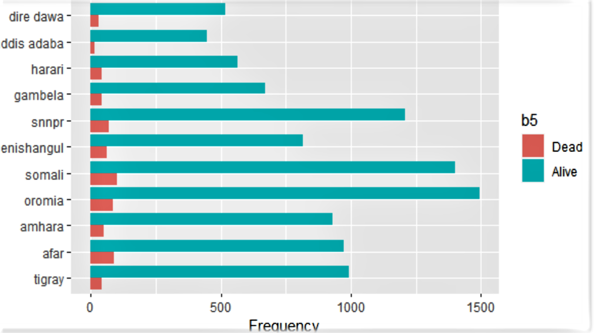

Fig 1: Bar graph

Descriptive analysis is performed for the association between the response and explanatory variables. Table 2 below shows the association of the explanatory variables to the outcome variable.

Table 2: Respondents Characteristics

| **Variable** | **N** | **Overall**, N = 10,641<sup>1</sup> | **Alive**, N = 10,006<sup>1</sup> | **Dead**, N = 635<sup>1</sup> | **p-value**<sup>2</sup> |
| --- | --- | --- | --- | --- | --- |
| v024 | 10,641 |  |  |  | <0.001 |
| addis adaba |  | 461 (4.3%) | 447 (4.5%) | 14 (2.2%) |  |
| afar |  | 1,062 (10.0%) | 972 (9.7%) | 90 (14%) |  |
| amhara |  | 977 (9.2%) | 928 (9.3%) | 49 (7.7%) |  |
| benishangul |  | 879 (8.3%) | 815 (8.1%) | 64 (10%) |  |
| dire dawa |  | 547 (5.1%) | 516 (5.2%) | 31 (4.9%) |  |
| gambela |  | 714 (6.7%) | 670 (6.7%) | 44 (6.9%) |  |
| harari |  | 605 (5.7%) | 564 (5.6%) | 41 (6.5%) |  |
| oromia |  | 1,581 (15%) | 1,494 (15%) | 87 (14%) |  |
| snnpr |  | 1,277 (12%) | 1,206 (12%) | 71 (11%) |  |
| somali |  | 1,505 (14%) | 1,402 (14%) | 103 (16%) |  |
| tigray |  | 1,033 (9.7%) | 992 (9.9%) | 41 (6.5%) |  |
| v025 | 10,641 |  |  |  | <0.001 |
| Rural |  | 8,667 (81%) | 8,099 (81%) | 568 (89%) |  |
| Urban |  | 1,974 (19%) | 1,907 (19%) | 67 (11%) |  |
| b11 | 10,641 |  |  |  | <0.001 |
| Less than 2 years |  | 3,020 (28%) | 2,747 (27%) | 273 (43%) |  |
| More than 2 years |  | 7,621 (72%) | 7,259 (73%) | 362 (57%) |  |
| m15 | 10,641 |  |  |  | <0.001 |
| Facility |  | 3,486 (33%) | 3,335 (33%) | 151 (24%) |  |
| Out of facility |  | 7,155 (67%) | 6,671 (67%) | 484 (76%) |  |

<sup>1</sup> n (%)  
<sup>2</sup> Pearson's Chi-squared test

The mortality estimation estimated from the space time modeling is explained from the spatial map generated as shown in figure 2.

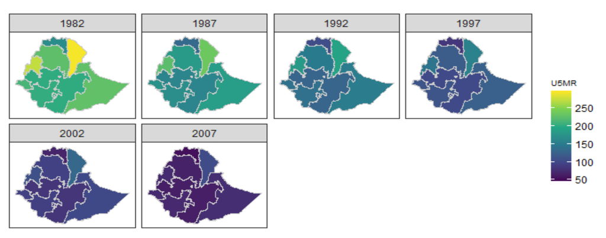

Fig 2: Subnational burden distribution of U5M across time

A direct mortality estimation is being used to estimate the national level estimates is shown in figure 3 and 4 below. Also, 95% Uncertainty intervals are also estimated for the national estimate. Similarly, figure 5 displays the sub-national trends of burden is computed and compared.

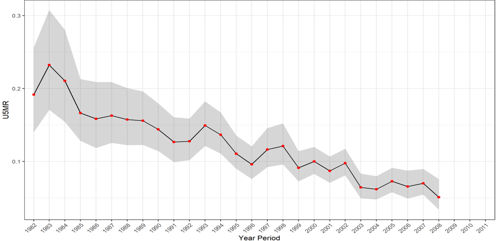

Fig 3: Direct mortality estimation of U5M.

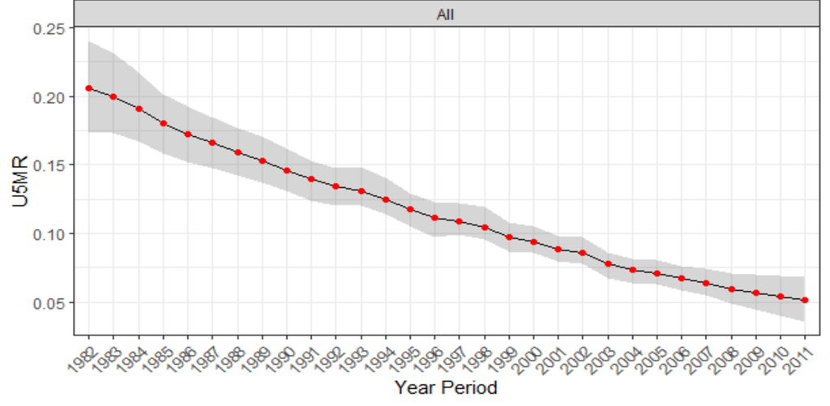

Fig 4: Smoothed Direct mortality estimation of U5M.

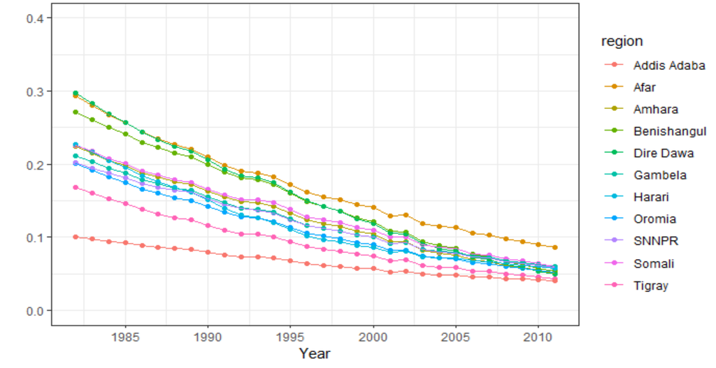

### Contributors

- Kemal Sherefa
- Dereje Yada
- Nahom A. Worku